# Maximum cumulative ratio approach and classification management

Gauthier Magnin

Last update: 2022-11-02

Proposed as a tool for the assessment of occupational exposure to chemical agents, the **Maximum Cumulative Ratio approach** helps determine whether a cumulative risk assessment is necessary.

This approach proposes a set of indicators. The main one (the maximum cumulative ratio) is defined as the ratio of the cumulative toxicity received by an individual from exposure to multiple chemical stressors to the largest toxicity from a single chemical stressor. The maximum cumulative ratio is a quantitiative measure of the difference in an individual’s toxicity estimated using a chemical-by-chemical approach and using an additive model of toxicity. As such, it provides a conservative estimate of the degree to which individuals’ toxicities could be underestimated by not performing a cumulative risk assessment.

Nevertheless, as the indicators of the Maximum Cumulative Ratio approach are based only on **effective values** and **reference values**, they can be applied to other fields and situations in which we would like to know the importance of the **cumulative aspect** compared to the **individual aspect**.

This document describes the Maximum Cumulative Ratio approach by providing an example of application to occupational co-exposure data. The first section prepares the data that are used in other sections. The second one applies the approach to these data, computing indicators and plotting graphs. The third section proposes to apply this approach by considering a classification of the substances the data are from. Finally, the last one presents some computations and formatting of a classification system in general, and additional transformations on the structure containing the values being analyzed.

```r
library(uom.dat)
```

# 1. Data preparation

## 1.1. Effective values

Foremost, we will create a list of effective values. This will be a list of numeric named vectors.

The following creates a list of transactions as presented in the document Transaction sets using the dataset `oedb_sample`. For short, these transactions will simply group data from this dataset accessible in the package. Note that this step is not necessary: the `TransactionSet` structure will only be used as an intermediary to get values to analyze for the examples.

```r
# Creation of specific transactions
transactions <- make_OE_transactions(
  oedb_sample,
  keys = c("ID", "CODE", "YEAR"),
  mode = 1,
  work_situations = data.frame(WS.ID = c(1, 2, 2, 3, 3),
                               JOB.TITLE = c(44121004, 44142001, 44132032, 44132019, 44132030),
                               JOB.TASK = c("A5440", "A6410", "A5110", "A5260", "A5240"),
                               stringsAsFactors = FALSE),
  variable_names = c("JOB.TITLE", "JOB.TASK"),
  additional = c("NAME", "CONCENTRATION", "SAMPLE.ID", "JOB.TITLE", "JOB.TASK"),
  unique_values = c("JOB.TITLE", "JOB.TASK")
)

print(transactions)
```

```
## TransactionSet
##   data:     14 transactions
##   names:    "CODE", "YEAR", "ID", "NAME", "CONCENTRATION", "SAMPLE.ID", "JOB.TITLE", "JOB.TASK"
##   item_key: "CODE"
##   year_key: "YEAR"
```

These transactions contain names, concentrations and identifiers of chemicals, identifiers and year of the sampling and extra information about the profession for which the environment has been sampled.

The following separates the concentration values and name them with the substances they correspond to. The resulting list of named values will have the same length as the list of transactions: 14 elements.

```r
concentration_values <- lapply(transactions["data"],
                               function(trx) setNames(trx$CONCENTRATION, trx$NAME))

# Naming the sets of values: S1 to S14
names(concentration_values) <- paste0("S", seq_along(concentration_values))

# Let's take a look at one set of values
concentration_values[[2]]
```

```
## Formaldéhyde Formaldéhyde      Benzène
##        0.007        0.004        0.050
```

The analysis will be carried out on these sets of concentration values.

Note that several values can correspond to the same component name. As we can see from the previous printed set of values, two values correspond to a chemical substance named “Formaldéhyde” and the last value corresponds to another one named “Benzène”. In such a case, if we want to perform the analysis considering a single value for each different name, we need to format the data. One way to do so is presented further in section 4.2.2. Reduction of sets of values.

## 1.2. Classification

Now let’s take a look at the classification which will be used concerning the substances the values are from. This classification is the `TOXICITY` variable of the dataset `substances_information` which is accessible in the package. Here is a example of it:

```r
substances_information[349:353, c("CODE", "NAME", "TOXICITY")]
```

|  | CODE | NAME | TOXICITY |
| --- | --- | --- | --- |
| 349 | 462 | Acrylate de méthyle | Atteintes oculaires , Atteintes oculaires , Atteintes des voies respiratoires supérieures, Atteintes cutanées , Sensibilisants |
| 350 | 1036 | Acrylate de n-butyle | Atteintes oculaires , Atteintes des voies respiratoires supérieures, Atteintes cutanées , Sensibilisants |
| 351 | 106 | Acétate d’isobutyle | NULL |
| 352 | 105 | Acétate d’isopentyle | Atteintes des voies respiratoires supérieures |
| 353 | 23 | Acétate d’isopropyle | NULL |

As we can see, some substances are associated to one or more classes while others are not associated with any class.

To use this classification, we have to extract the `TOXICITY` list and name the elements with the associated `NAME`s:

```r
classification <- substances_information$TOXICITY
names(classification) <- substances_information$NAME
```

We can then get the names of all our classes:

```r
class_names <- sort(unique(unlist(classification)))
class_names
```

```
##  [1] "Atteintes cardio-vasculaires"
##  [2] "Atteintes cutanées"
##  [3] "Atteintes des voies respiratoires inférieures"
##  [4] "Atteintes des voies respiratoires supérieures"
##  [5] "Atteintes du système auditif"
##  [6] "Atteintes du système hématopoïétique"
##  [7] "Atteintes du système immunitaire"
##  [8] "Atteintes du système nerveux autonome"
##  [9] "Atteintes du système nerveux central"
## [10] "Atteintes du système nerveux périphérique"
## [11] "Atteintes du système reproducteur féminin"
## [12] "Atteintes du système reproducteur masculin"
## [13] "Atteintes hépatiques"
## [14] "Atteintes oculaires"
## [15] "Atteintes osseuses et dentaires"
## [16] "Atteintes rénales et de l'appareil urinaire"
## [17] "Atteintes sur le développement du fœtus, de l’embryon et/ou de l’enfant"
## [18] "Effets cancérogènes et/ou mutagènes"
## [19] "Perturbateur endocrinien"
## [20] "Perturbation du transport de l'oxygène"
## [21] "Sensibilisants"
```

## 1.3. Reference values

Finally, we must have references values. This will be a numeric named vector.

The dataset `substances_information` also contains the reference value of each substance in the variable `LIMIT`. However, some of the substances have no value for this variable. We will therefore set an arbitrary limit value for these variables without reference:

```r
# First, let's check that the value we are going to assign will be unique to substances
# that have no limit
cat("Number of substances having the limit 35:",
    sum(substances_information$LIMIT == 35, na.rm = TRUE))
```

```
## Number of substances having the limit 35: 0
```

```r
# We could also keep a vector defining whether a substance had a limit
no_limit <- is.na(substances_information$LIMIT)

# Extract the limits in a new variable and setting a new limit for missing values
reference_values <- substances_information$LIMIT
reference_values[no_limit] <- 35
```

Now we have to name the vector of limits to easily understand which limit is for which substance and extract the subset of references corresponding to the substances the concentrations are for:

```r
# Naming the vector with the substances the limits are associated with
names(reference_values) <- substances_information$NAME

# Extraction of the names related to the concentrations and removing the duplicates
substance_names <- unique(unlist(lapply(concentration_values, names)))
cat("Number of distinct substances:", length(substance_names))
```

```
## Number of distinct substances: 25
```

```r
# Extraction of the limits related to the concentrations
reference_values <- reference_values[substance_names]

# Let's see what we have
cat("A subset of the reference values:\n")
reference_values[1:4]
```

```
## A subset of the reference values:
##  Méthacrylate de butyle Méthacrylate de méthyle                 Ethanol
##                   35.00                  205.00                 1900.00
##            Formaldéhyde
##                    0.61
```

# 2. Application of the MCR approach

## 2.1. Summary and specific indicators

### 2.1.1. Compute a summary of the indicators

The indicators of the MCR approach (short for Maximum Cumulative Ratio approach) can be computed using a single function: `mcr_summary`.

```r
cat("Number of sets of values:",
    length(concentration_values))
```

```
## Number of sets of values: 14
```

```r
# Computing the indicators of the MCR approach
mcr_summary(values = concentration_values,
            references = reference_values,
            ignore_zero = FALSE)
```

|  | n | HI | MCR | Reciprocal | Group | THQ | MHQ | Missed |
| --- | --- | --- | --- | --- | --- | --- | --- | --- |
| S1 | 24 | 0.2320246 | 7.927506 | 0.1261431 | II | Méthacrylate de méthyle | 0.0292683 | 0.8738569 |
| S2 | 3 | 0.0334174 | 2.172131 | 0.4603774 | II | Benzène | 0.0153846 | 0.5396226 |
| S3 | 21 | 16.9290200 | 3.111952 | 0.3213417 | I | Styrène | 5.4400000 | 0.6786583 |
| S4 | 4 | 2.4571429 | 2.047619 | 0.4883721 | I | Hydrocarbures aliphatiques et alicycliques | 1.2000000 | 0.5116279 |
| S5 | 1 | 0.6290000 | 1.000000 | 1.0000000 | II | Poussières inhalables | 0.6290000 | 0.0000000 |
| S6 | 3 | 1.4598755 | 1.064493 | 0.9394147 | I | Hydrocarbures aliphatiques et alicycliques | 1.3714286 | 0.0605853 |
| S7 | 10 | 0.7795714 | 2.547619 | 0.3925234 | II | Poussières inhalables | 0.3060000 | 0.6074766 |
| S8 | 15 | 20.0747508 | 1.103008 | 0.9066115 | I | Hydrocarbures aliphatiques et alicycliques | 18.2000000 | 0.0933885 |
| S9 | 30 | 33.0336045 | 3.451787 | 0.2897050 | I | Styrène | 9.5700000 | 0.7102950 |
| S10 | 6 | 0.0800000 | 5.333333 | 0.1875000 | II | 4,4’-Diisocyanate de diphénylméthane | 0.0150000 | 0.8125000 |
| S11 | 6 | 5.0122857 | 1.518874 | 0.6583823 | I | Chrome VI et ses composés | 3.3000000 | 0.3416177 |
| S12 | 5 | 0.1755714 | 1.340240 | 0.7461351 | II | Poussières inhalables | 0.1310000 | 0.2538649 |
| S13 | 2 | 0.9700000 | 1.293333 | 0.7731959 | II | Chrome VI et ses composés | 0.7500000 | 0.2268041 |
| S14 | 1 | 0.1050000 | 1.000000 | 1.0000000 | II | Poussières inhalables | 0.1050000 | 0.0000000 |

We can see that the output data frame has 14 rows: one for each set of values. It has 8 columns: one reminding the number of values and seven others for the seven indicators:

- **n**: number of values.
- **HI**: Hazard Index.
- **MCR**: Maximum Cumulative Ratio.
- **Reciprocal**: Reciprocal of the maximum cumulative ratio.
- **Group**: MIAT group.
- **THQ**: Top Hazard Quotient.
- **MHQ**: Maximum Hazard Quotient.
- **Missed**: Missed toxicity.

The argument `ignore_zero` allows to ignore values equal to $0$. If so, the column named `n` specifies the number of values considered and an additional column named `n_zero` specifies the number of values ignored. Ignoring such values has no impact on the indicators computed on a set of values if at least one of these values is different from $0$.

### 2.1.2. Definition of the indicators

**Hazard Index**: sum of hazard quotients, i.e. sum of ratios between values and reference values. The hazard index of the vector of values $V$ is given by:
$$HI = \sum_{i=1}^{n} HQ_{i} =
\sum_{i=1}^{n} \frac{V_i}{RV_i}$$
where $n$ denotes the length of the vector $V$ (i.e. the number of values), $HQ$ denotes the hazard quotients, $V$ the values and $RV$ the reference values.

**Maximum Hazard Quotient**: the primary hazard quotient. It is given by:
$$MHQ = \max_{i
\in \lbrace 1,...,n\rbrace} HQ_i = \max_{i \in \lbrace 1,...,n\rbrace}
\frac{V_i}{RV_i}$$
where $n$ denotes the length of the vector $V$ (i.e. the number of values), $HQ$ denotes the hazard quotients, $V$ the values and $RV$ the reference values.

**Top Hazard Quotient**: named value that produces the highest hazard quotient.

**Maximum Cumulative Ratio**: ratio between a hazard index and a maximum hazard quotient. It represents the magnitude of the hazard that is underestimated by not performing a cumulative risk assessment. It is bounded by $1$ and $n$, the number of components. A value close to $1$ means that one component is responsible for nearly all the toxicity. A value of $n$ means that all components have equal toxicities. The maximum cumulative ratio is given by:
$$MCR = \frac{HI}{MHQ}$$

**Reciprocal of the maximum cumulative ratio**: the inverse of the maximum cumulative ratio. It measures the percentage contribution of the maximum hazard quotient to the total hazard. It is given by:
$$Reciprocal~of~MCR =
\frac{1}{MCR} = \frac{MHQ}{HI}$$

**Missed toxicity**: hazard missed if a cumulative risk assessment is not performed. It is given by:
$$Missed~toxicity = 1 - \frac{1}{MCR}$$

**MIAT group**: groups according to the CEFIC-MIAT (Mixtures Industry Ad-hoc Team) decision tree. Each group requires a different risk management strategy as they describe the following situations:

- **Group I**: the mixture presents a potential risk already based on individual components.
- **Group II**: the assessment does not identify a concern.
- **Group IIIA**: the majority of the risk offered by the mixture is driven by one component.
- **Group IIIB**: the potential risk is driven by multiple components.

The vector of values $V$ is assigned to a group according to the following conditions.

- Group I: $MHQ \ge 1$
- Group II: $MHQ < 1, ~ HI \le 1$
- Group IIIA: $MHQ < 1, ~ HI > 1, ~ MCR < 2$
- Group IIIB: $MHQ < 1, ~ HI > 1, ~ MCR \ge 2$

Given these definitions, in the case of a vector containing only values equal to $0$, all indicators can be considered equal to $0$ and the corresponding top hazard quotient and MIAT group to be `NA` and the group II respectively.

### 2.1.3. Compute a specific indicator

All indicators of the MCR approach can be computed independantly by a specific function, for a specific set of values. The functions are the following:

- `hazard_quotient`: compute hazard quotients.
- `hazard_index`: compute hazard indexes.
- `maximum_hazard_quotient`: compute and identify maximum hazard quotients.
- `maximum_cumulative_ratio`: compute maximum cumulative ratios.
- `reciprocal_of_mcr`: compute reciprocals of maximum cumulative ratios.
- `missed_toxicity`: compute missed toxicities.
- `top_hazard_quotient`: compute and identify highest hazard quotients.
- `classify_mixture`: classify in the MIAT groups.

```r
# Extraction of the names related to the second set of concentrations
substance_names_2 <- unlist(names(concentration_values[[2]]))

# Compute each of the indicators one by one, for the values of the second set of concentrations

cat("Hazard quotients:\n")
hazard_quotient(values = concentration_values[[2]],
                references = reference_values[substance_names_2])

cat("\nHazard index:\n")
hazard_index(values = concentration_values[[2]],
             references = reference_values[substance_names_2])

cat("\nMaximum hazard quotient:\n")
maximum_hazard_quotient(values = concentration_values[[2]],
                        references = reference_values[substance_names_2])

cat("\nMaximum cumulative ratio:\n")
maximum_cumulative_ratio(values = concentration_values[[2]],
                         references = reference_values[substance_names_2])

cat("\nReciprocal of the maximum cumulative ratio:\n")
reciprocal_of_mcr(values = concentration_values[[2]],
                  references = reference_values[substance_names_2])

cat("\nMissed toxicity:\n")
missed_toxicity(values = concentration_values[[2]],
                references = reference_values[substance_names_2])

cat("\nTop hazard quotient:\n")
top_hazard_quotient(values = concentration_values[[2]],
                    references = reference_values[substance_names_2],
                    k = 1)

cat("\nMIAT group:\n")
classify_mixture(values = concentration_values[[2]],
                 references = reference_values[substance_names_2])
```

```
## Hazard quotients:
## Formaldéhyde Formaldéhyde      Benzène
##  0.011475410  0.006557377  0.015384615
##
## Hazard index:
## [1] 0.0334174
##
## Maximum hazard quotient:
## [1] 0.01538462
##
## Maximum cumulative ratio:
## [1] 2.172131
##
## Reciprocal of the maximum cumulative ratio:
## [1] 0.4603774
##
## Missed toxicity:
## [1] 0.5396226
##
## Top hazard quotient:
##    Benzène
## 0.01538462
##
## MIAT group:
## [1] "II"
```

In the function `top_hazard_quotient`, the argument `k` defines how many of the highest hazard quotients to look for. Default is a number of top hazard quotients equal to the integer part of the maximum cumulative ratio computed from the same values and references. This function also has an argument `ignore_zero` to choose whether to ignore values equal to $0$.

## 2.2. Scatter plot

### 2.2.1. Simple scatter plot

The hazard index and the maximum cumulative ratio can be visualized by plotting $HI$ versus $MCR$ and displaying the percentage of the reciprocal of the maximum cumulative ratio, the elements producting the top hazard quotients and the associated MIAT groups. The function to use for this is `mcr_chart`.

```
## Warning in mcr_chart(values = concentration_values, references =
## reference_values): 2 points have not been plotted because their MCR values are
## equal to 1. Use log_transform = FALSE to see all points.
```

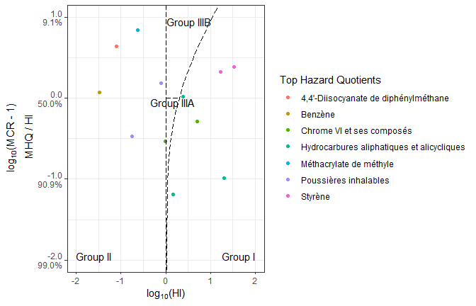

```r
mcr_chart(values = concentration_values,
          references = reference_values)
```

### 2.2.2. Arguments of the scatter plot

#### Logarithmic transformation

As described in the previous warning message, points having $MCR$ equal to $1$ cannot be plotted (because $log_{10}(MCR - 1)$ is then equal to $-Inf$). In this case, an alternative chart can be plotted using the argument `log_transform` which enable or disable the logarithmic transformation:

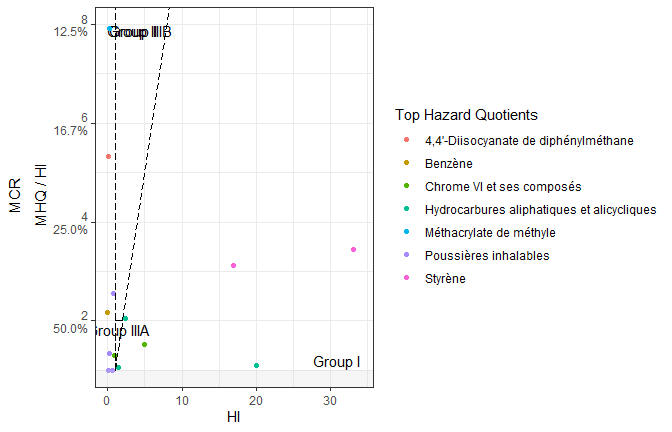

```r
mcr_chart(values = concentration_values,
          references = reference_values,
          log_transform = FALSE)
```

Note that in both cases, sets of values containing only values equal to $0$ (i.e., having $MCR$ values equal to $0$) are not plotted.

#### Coloring regions

Other parameters allow to better identify the points. For chart like this one with a wide range of abscissa, group labels cannot be clearly visible. The argument `regions` allows to hide the labels and color the regions related to the MIAT groups:

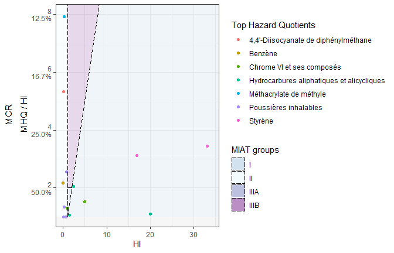

```r
mcr_chart(values = concentration_values,
          references = reference_values,
          regions = TRUE,
          log_transform = FALSE)
```

The grey region is the one in which no point can be plotted because the maximum cumulative ratio cannot be lower than $1$.

#### ggplot2

The chart being plotted with the `ggplot2` package, it can be modified or completed afterwards using the ggplot2 `last_plot` function or the returned object. We can for example change the limits:

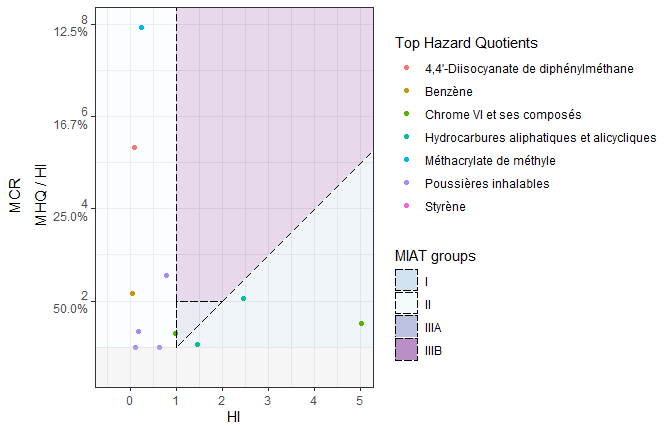

```r
# Loading the package
library(ggplot2)

# Make changes to the last plot
last_plot() + coord_cartesian(xlim = c(-0.5, 5),
                              ylim = c(0.5, 8))
```

#### Colors of the top hazard quotients

The argument `thq_col` allows to assign specific colors to the top hazard quotients. For the following examples, let’s go back to the logarithm form of the chart:

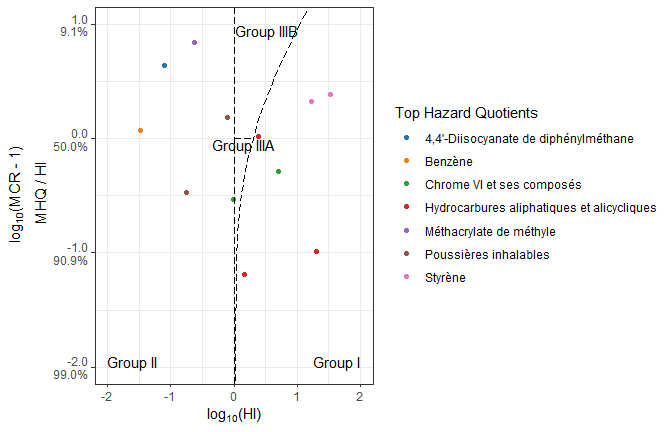

```r
# Loading color library for a palette of 20 colors
library(ggsci)
palette <- pal_d3("category20")(20)

# Because there are more than 20 references, we need to use extra colors
new_thq_col <- c(palette[1:20], "red", "green", "blue", "yellow", "black")

mcr_chart(values = concentration_values,
          references = reference_values,
          thq_col = new_thq_col)
```

Note that, if the new colors are not named, they are associated with the top hazard quotients in the given order (the first color for the first THQ in the legend, and so on). If they are named, colors are explicitly associated with the possible values of the top hazard quotients (in our case, that would be with the substance names).

#### Colors and transparency of the regions

The arguments `regions_col` and `regions_alpha` allow to specify the colors and transparency of the regions:

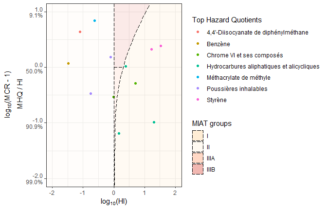

```r
mcr_chart(values = concentration_values,
          references = reference_values,
          regions = TRUE,
          regions_col = c("#fdcc8a", "#fef0d9", "#fc8d59", "#d7301f"),
          regions_alpha = 0.1)
```

Note that default region colors are colorblind safe and print friendly. If you are interested in such properties, I suggest you to use tools like the following website: [Color Brewer 2.0](https://colorbrewer2.org).

#### Region labels

The argument `regions_lab` allows to specify which of the four labels related to the MIAT groups to display:

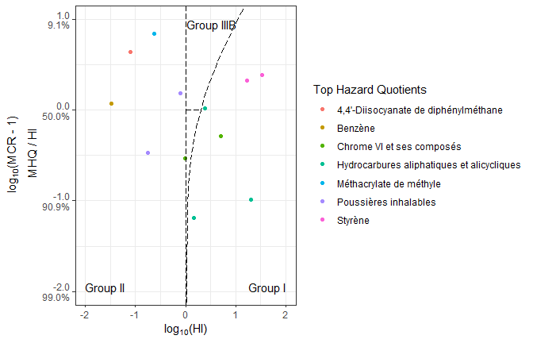

```r
mcr_chart(values = concentration_values,
          references = reference_values,
          regions_lab = c(TRUE, TRUE, FALSE, TRUE))
```

#### Linear regression

Finally, we can easily plot the linear regression between the X and Y coordinates of the points with 95% confidence interval using the argument `regression`:

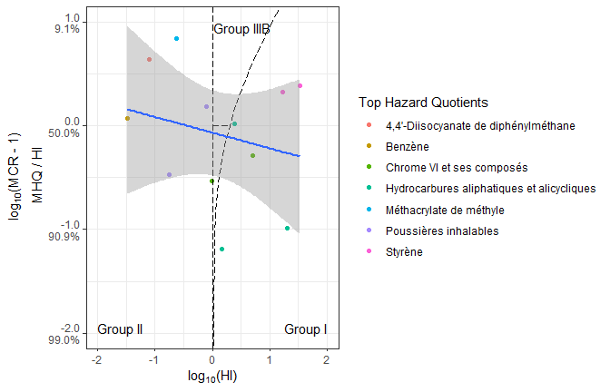

```r
mcr_chart(values = concentration_values,
          references = reference_values,
          regions_lab = c(TRUE, TRUE, FALSE, TRUE),
          regression = TRUE)
```

## 2.3. Contingency tables

Two types of contingency tables can be built on the indicators of the MCR approach:

- The counts of each combination of the top two hazard quotients for which the associated hazard index is greater than $1$, using the function `thq_pairs`.
- The counts of each combination of the top hazard quotient with the associated MIAT group, using the function `thq_by_group`.

```r
# Frequencies of the pairs that produce the top two hazard quotients while hazard index
# is greater than 1
thq_pairs(values = concentration_values,
          references = reference_values)
```

```
##                                            Butanone Chrome total
## Butanone                                          0            0
## Chrome total                                      0            0
## Chrome VI et ses composés                         0            1
## Hydrocarbures aliphatiques et alicycliques        1            0
## Styrène                                           0            0
## Toluène                                           0            0
##                                            Chrome VI et ses composés
## Butanone                                                           0
## Chrome total                                                       1
## Chrome VI et ses composés                                          0
## Hydrocarbures aliphatiques et alicycliques                         0
## Styrène                                                            0
## Toluène                                                            0
##                                            Hydrocarbures aliphatiques et alicycliques
## Butanone                                                                            1
## Chrome total                                                                        0
## Chrome VI et ses composés                                                           0
## Hydrocarbures aliphatiques et alicycliques                                          1
## Styrène                                                                             0
## Toluène                                                                             1
##                                            Styrène Toluène
## Butanone                                         0       0
## Chrome total                                     0       0
## Chrome VI et ses composés                        0       0
## Hydrocarbures aliphatiques et alicycliques       0       1
## Styrène                                          2       0
## Toluène                                          0       0
```

```r
# Frequencies of elements that produce the top hazard quotient with their associated groups
thq_by_group(values = concentration_values,
             references = reference_values)
```

```
##                                            I II IIIA IIIB
## 4,4'-Diisocyanate de diphénylméthane       0  1    0    0
## Benzène                                    0  1    0    0
## Chrome VI et ses composés                  1  1    0    0
## Hydrocarbures aliphatiques et alicycliques 3  0    0    0
## Méthacrylate de méthyle                    0  1    0    0
## Poussières inhalables                      0  4    0    0
## Styrène                                    2  0    0    0
```

For both functions, the argument `levels` can be used to get the full table, i.e. with component names that do not produce any top hazard quotient:

```r
table_levels <- names(reference_values)[-19]
# For readability of the example, intentional removal of the 19th name which is quite long

thq_by_group(values = concentration_values,
             references = reference_values,
             levels = sort(table_levels))
```

```
##                                            I II IIIA IIIB
## 1-Méthoxypropane-2-ol                      0  0    0    0
## 4,4'-Diisocyanate de diphénylméthane       0  1    0    0
## Acétate de n-butyle                        0  0    0    0
## Acétone                                    0  0    0    0
## Aluminium                                  0  0    0    0
## Argent métallique                          0  0    0    0
## Benzène                                    0  1    0    0
## Butanone                                   0  0    0    0
## Chrome total                               0  0    0    0
## Chrome VI et ses composés                  1  1    0    0
## Cuivre                                     0  0    0    0
## Ethanol                                    0  0    0    0
## Fer                                        0  0    0    0
## Formaldéhyde                               0  0    0    0
## Fumées de soudage                          0  0    0    0
## Hydrocarbures aliphatiques et alicycliques 3  0    0    0
## Manganèse                                  0  0    0    0
## Méthacrylate de butyle                     0  0    0    0
## Méthacrylate de méthyle                    0  1    0    0
## Nickel                                     0  0    0    0
## Poussières inhalables                      0  4    0    0
## Styrène                                    2  0    0    0
## Toluène                                    0  0    0    0
## Zinc                                       0  0    0    0
```

They also have an argument `ignore_zero` to choose whether to ignore values equal to $0$.

For the first of the two functions (`thq_pairs`), two other arguments exists:

- `threshold`, allowing to disable the condition over the hazard index so that top hazard quotients associated with hazard index less than or equal to $1$ are taken into account.
- `alone`, to also consider single top hazard quotients (i.e. top hazard quotients from sets of one single value). The resulting top hazard quotients are associated with a level named `"NULL"`.

```r
# Frequencies of the pairs that produce the top two hazard quotients without condition
# over the hazard indexes and over the lengths of the sets of values (i.e. all sets
# of values are considered)
thq_pairs(values = concentration_values,
          references = reference_values,
          threshold = FALSE, alone = TRUE)
```

```
##                                            4,4'-Diisocyanate de diphénylméthane
## 4,4'-Diisocyanate de diphénylméthane                                          1
## Benzène                                                                       0
## Butanone                                                                      0
## Chrome total                                                                  0
## Chrome VI et ses composés                                                     0
## Formaldéhyde                                                                  0
## Fumées de soudage                                                             0
## Hydrocarbures aliphatiques et alicycliques                                    0
## Manganèse                                                                     0
## Méthacrylate de butyle                                                        0
## Méthacrylate de méthyle                                                       0
## Poussières inhalables                                                         0
## Styrène                                                                       0
## Toluène                                                                       0
## NULL                                                                          0
##                                            Benzène Butanone Chrome total
## 4,4'-Diisocyanate de diphénylméthane             0        0            0
## Benzène                                          0        0            0
## Butanone                                         0        0            0
## Chrome total                                     0        0            0
## Chrome VI et ses composés                        0        0            1
## Formaldéhyde                                     1        0            0
## Fumées de soudage                                0        0            0
## Hydrocarbures aliphatiques et alicycliques       0        1            0
## Manganèse                                        0        0            0
## Méthacrylate de butyle                           0        0            0
## Méthacrylate de méthyle                          0        0            0
## Poussières inhalables                            0        0            0
## Styrène                                          0        0            0
## Toluène                                          0        0            0
## NULL                                             0        0            0
##                                            Chrome VI et ses composés
## 4,4'-Diisocyanate de diphénylméthane                               0
## Benzène                                                            0
## Butanone                                                           0
## Chrome total                                                       1
## Chrome VI et ses composés                                          0
## Formaldéhyde                                                       0
## Fumées de soudage                                                  1
```

[output cut: 89 more lines]

```
## 4,4'-Diisocyanate de diphénylméthane             0    0
## Benzène                                          0    0
## Butanone                                         0    0
## Chrome total                                     0    0
## Chrome VI et ses composés                        0    0
## Formaldéhyde                                     0    0
## Fumées de soudage                                0    0
## Hydrocarbures aliphatiques et alicycliques       1    0
## Manganèse                                        0    0
## Méthacrylate de butyle                           0    0
## Méthacrylate de méthyle                          0    0
## Poussières inhalables                            0    2
## Styrène                                          0    0
## Toluène                                          0    0
## NULL                                             0    0
```

## 2.4. Additional analysis

Several useful indicators can be computed complementarily to the MCR approach. Here we will present few examples.

```r
# Computing the indicators of the MCR approach
mcr_s <- mcr_summary(values = concentration_values,
                     references = reference_values)
```

First, the correlation of $MCR - 1$ against $HI$.

A negative correlation (i.e. $MCR - 1$ declines as $HI$ increases) indicates that the majority of the risks comes from single components and that risk mitigation could focus on these individual components. A positive correlation indicates that the highest risks are produced by the accumulation of several components and that tracking these cumulation situations is required to fully characterize risks.

```r
cor(x = mcr_s$HI,
    y = mcr_s$MCR - 1)
```

```
## [1] 0.01979126
```

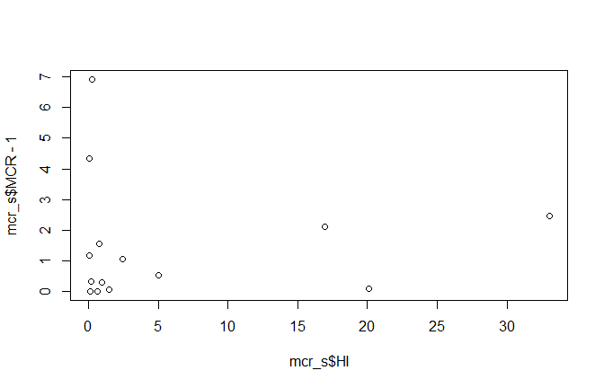

```r
plot(x = mcr_s$HI,
     y = mcr_s$MCR - 1)
```

Then, the temporal trend of one indicator, for instance the hazard index:

```r
# Use of the year information associated with the concentration values
# in the original dataset and in the transactions created
cor(x = unlist(transactions["YEAR"]),
    y = mcr_s$HI)
```

```
## [1] 0.1845357
```

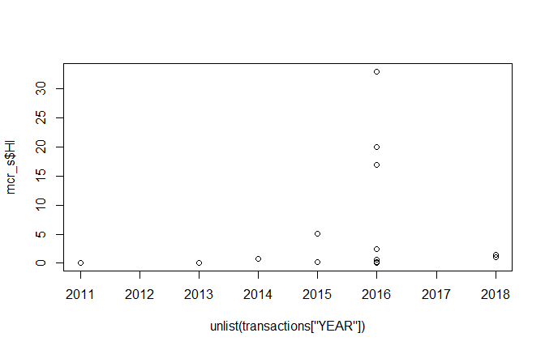

```r
plot(x = unlist(transactions["YEAR"]),
     y = mcr_s$HI)
```

Finally, summaries of indicators according to the groups:

```r
# Sets of groups and of indicators
groups <- c("I", "II", "IIIA", "IIIB")
indicators <- c("HI", "MCR", "MHQ", "Missed")

# Compute for each group, the summary of the results of each indicator
list_of_summaries <-
  lapply(groups, function(group) {
    sapply(indicators, function(indicator) {
      summary(mcr_s[mcr_s$Group == group, indicator])
    })
  })
names(list_of_summaries) <- groups

list_of_summaries
```

```
## $I
##                HI      MCR       MHQ     Missed
## Min.     1.459876 1.064493  1.200000 0.06058528
## 1st Qu.  3.095929 1.206975  1.853571 0.15544581
## Median  10.970653 1.783247  4.370000 0.42662282
## Mean    13.161113 2.049622  6.513571 0.39936212
## 3rd Qu. 19.288318 2.845869  8.537500 0.63690071
## Max.    33.033605 3.451787 18.200000 0.71029501
##
## $II
##                HI      MCR        MHQ    Missed
## Min.    0.0334174 1.000000 0.01500000 0.0000000
## 1st Qu. 0.0987500 1.220000 0.02579737 0.1701031
## Median  0.2037980 1.756186 0.11800000 0.3967438
## Mean    0.3755731 2.826770 0.24758161 0.4142657
## 3rd Qu. 0.6666429 3.244048 0.38675000 0.6587325
## Max.    0.9700000 7.927506 0.75000000 0.8738569
##
## $IIIA
##          HI MCR MHQ Missed
## Min.     NA  NA  NA     NA
## 1st Qu.  NA  NA  NA     NA
## Median   NA  NA  NA     NA
## Mean    NaN NaN NaN    NaN
## 3rd Qu.  NA  NA  NA     NA
## Max.     NA  NA  NA     NA
##
## $IIIB
##          HI MCR MHQ Missed
## Min.     NA  NA  NA     NA
## 1st Qu.  NA  NA  NA     NA
## Median   NA  NA  NA     NA
## Mean    NaN NaN NaN    NaN
## 3rd Qu.  NA  NA  NA     NA
## Max.     NA  NA  NA     NA
```

`NA` and `NaN` are returned for the last two groups because no set of values has been classified in these groups.

# 3. Application of the MCR approach according to a classification

As described in section 1.2. Classification, we will use the classification present in the variable `TOXICITY` of the dataset `substances_information`. It associates classes with substances and looks like that:

```r
classification[350:352]
```

```
## $`Acrylate de n-butyle`
## [1] "Atteintes oculaires"
## [2] "Atteintes des voies respiratoires supérieures"
## [3] "Atteintes cutanées"
## [4] "Sensibilisants"
##
## $`Acétate d'isobutyle`
## NULL
##
## $`Acétate d'isopentyle`
## [1] "Atteintes des voies respiratoires supérieures"
```

Apply the MCR approach according to a classification means apply it depending on the different classes associated with the values. In other words, indicators will be computed for each subset of values related to a specific class, and for each class. For that, we can call the function `mcr_approach_by_class` with the values, the references, the classification and the function of the approach we want to apply.

Note that functions presented in section 2.1.3. Compute a specific indicator cannot be used via `mcr_approach_by_class`. However, specific indicators can be easily extracted from the data frames returned by the use of `mcr_summary`.

## 3.1. MCR summary according to classes

Concerning the summary of the indicators, for each class encountered, summaries are given for the sets of values relating to the class:

```r
# Make the summary for each class and each set of values
summaries <- mcr_approach_by_class(values = concentration_values,
                                   references = reference_values,
                                   classes = classification,
                                   FUN = mcr_summary)

cat("Number of classes encountered:", length(summaries))
```

```
## Number of classes encountered: 15
```

The resulting list has a length of 15, which mean that the analyzed values are related to 15 different classes.

```r
# Just look at few examples:
# summaries of the 6th and 7th classes
summaries[6:7]
```

```
## $`Atteintes du système immunitaire`
```

|  | n | n_zero | HI | MCR | Reciprocal | Group | THQ | MHQ | Missed |
| --- | --- | --- | --- | --- | --- | --- | --- | --- | --- |
| S2 | 1 | 0 | 0.0153846 | 1 | 1 | II | Benzène | 0.0153846 | 0 |

```
## $`Atteintes du système nerveux central`
```

|  | n | n_zero | HI | MCR | Reciprocal | Group | THQ | MHQ | Missed |
| --- | --- | --- | --- | --- | --- | --- | --- | --- | --- |
| S1 | 8 | 0 | 0.0205263 | 1.147059 | 0.8717949 | II | Ethanol | 0.0178947 | 0.1282051 |
| S3 | 21 | 0 | 16.9290200 | 3.111952 | 0.3213417 | I | Styrène | 5.4400000 | 0.6786583 |
| S6 | 2 | 0 | 0.0884470 | 1.698182 | 0.5888651 | II | Toluène | 0.0520833 | 0.4111349 |
| S7 | 2 | 0 | 0.0220000 | 1.833333 | 0.5454545 | II | Manganèse | 0.0120000 | 0.4545455 |
| S8 | 1 | 0 | 1.3133333 | 1.000000 | 1.0000000 | I | Butanone | 1.3133333 | 0.0000000 |
| S9 | 30 | 0 | 33.0336045 | 3.451787 | 0.2897050 | I | Styrène | 9.5700000 | 0.7102950 |
| S11 | 1 | 0 | 0.4100000 | 1.000000 | 1.0000000 | II | Manganèse | 0.4100000 | 0.0000000 |
| S12 | 1 | 0 | 0.0170000 | 1.000000 | 1.0000000 | II | Manganèse | 0.0170000 | 0.0000000 |

Two other arguments can be used:

- `by_set`, allowing to group the results by set of values instead of by class.
- `all_classes`, allowing to also get summaries of classes that are not related to a set of values. Only if `by_set` is `TRUE`.

```r
# Make the summary for each set of values and each class
summaries_2 <- mcr_approach_by_class(values = concentration_values,
                                     references = reference_values,
                                     classes = classification,
                                     FUN = mcr_summary,
                                     by_set = TRUE,
                                     all_classes = TRUE)

# Look at one example: the 11th set of values
summaries_2[["S11"]]
```

|  | n | n_zero | HI | MCR | Reciprocal | Group | THQ | MHQ | Missed |
| --- | --- | --- | --- | --- | --- | --- | --- | --- | --- |
| Atteintes cardio-vasculaires | 0 | 0 | NA | NA | NA | NA | NA | NA | NA |
| Atteintes cutanées | 2 | 0 | 3.630 | 1.100000 | 0.9090909 | I | Chrome VI et ses composés | 3.30 | 0.0909091 |
| Atteintes des voies respiratoires inférieures | 4 | 0 | 4.464 | 1.352727 | 0.7392473 | I | Chrome VI et ses composés | 3.30 | 0.2607527 |
| Atteintes des voies respiratoires supérieures | 3 | 0 | 4.054 | 1.228485 | 0.8140109 | I | Chrome VI et ses composés | 3.30 | 0.1859891 |
| Atteintes du système auditif | 0 | 0 | NA | NA | NA | NA | NA | NA | NA |
| Atteintes du système hématopoïétique | 0 | 0 | NA | NA | NA | NA | NA | NA | NA |
| Atteintes du système immunitaire | 0 | 0 | NA | NA | NA | NA | NA | NA | NA |
| Atteintes du système nerveux autonome | 0 | 0 | NA | NA | NA | NA | NA | NA | NA |
| Atteintes du système nerveux central | 1 | 0 | 0.410 | 1.000000 | 1.0000000 | II | Manganèse | 0.41 | 0.0000000 |
| Atteintes du système nerveux périphérique | 0 | 0 | NA | NA | NA | NA | NA | NA | NA |
| Atteintes du système reproducteur féminin | 0 | 0 | NA | NA | NA | NA | NA | NA | NA |
| Atteintes du système reproducteur masculin | 3 | 0 | 4.040 | 1.224242 | 0.8168317 | I | Chrome VI et ses composés | 3.30 | 0.1831683 |
| Atteintes hépatiques | 0 | 0 | NA | NA | NA | NA | NA | NA | NA |
| Atteintes oculaires | 2 | 0 | 3.630 | 1.100000 | 0.9090909 | I | Chrome VI et ses composés | 3.30 | 0.0909091 |
| Atteintes osseuses et dentaires | 0 | 0 | NA | NA | NA | NA | NA | NA | NA |
| Atteintes rénales et de l’appareil urinaire | 0 | 0 | NA | NA | NA | NA | NA | NA | NA |
| Atteintes sur le développement du fœtus, de l’embryon et/ou de l’enfant | 2 | 0 | 3.630 | 1.100000 | 0.9090909 | I | Chrome VI et ses composés | 3.30 | 0.0909091 |
| Effets cancérogènes et/ou mutagènes | 3 | 0 | 4.054 | 1.228485 | 0.8140109 | I | Chrome VI et ses composés | 3.30 | 0.1859891 |
| Perturbateur endocrinien | 0 | 0 | NA | NA | NA | NA | NA | NA | NA |
| Perturbation du transport de l’oxygène | 0 | 0 | NA | NA | NA | NA | NA | NA | NA |
| Sensibilisants | 3 | 0 | 4.054 | 1.228485 | 0.8140109 | I | Chrome VI et ses composés | 3.30 | 0.1859891 |

Additional arguments related to the function `mcr_summary` can also be used when calling `mcr_approach_by_class`.

## 3.2. Scatter plots according to classes

Concerning the scatter plot, one chart is built for each class and the result is a list.

```r
# Make one chart for each class
charts <- mcr_approach_by_class(values = concentration_values,
                                references = reference_values,
                                classes = classification,
                                FUN = mcr_chart)
```

[output not shown]

[output not shown]

[output not shown]

[output not shown]

At most one warning message can be printed by class. These messages must be read with regard to the stated subset of classes.

```r
cat("Number of charts (i.e. number of classes encountered):", length(charts))
```

```
## Number of charts (i.e. number of classes encountered): 15
```

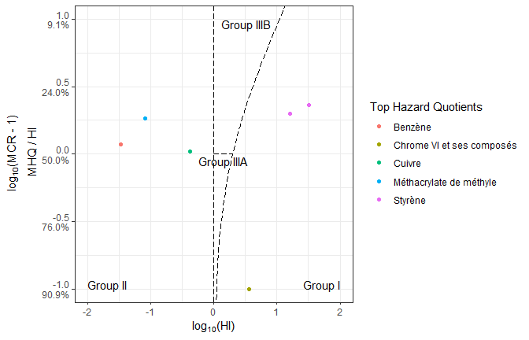

```r
# Plot some of these charts
charts[[1]]
```

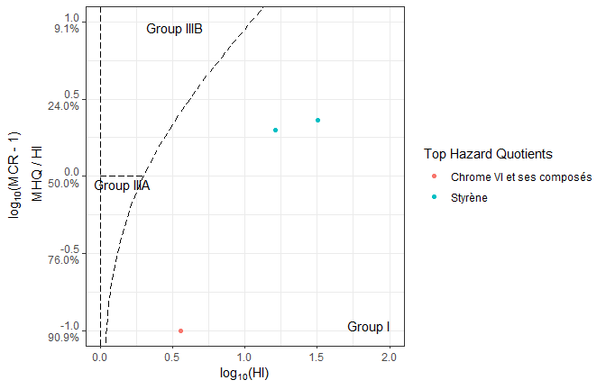

```r
charts[[12]]
```

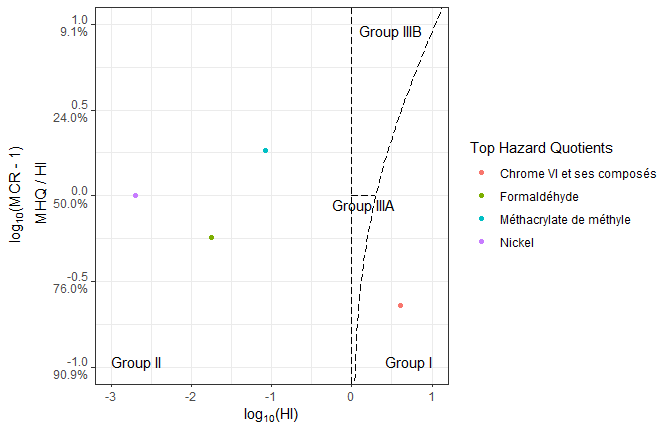

```r
charts[["Sensibilisants"]]
```

Additional arguments related to the function `mcr_chart` can be used. For example:

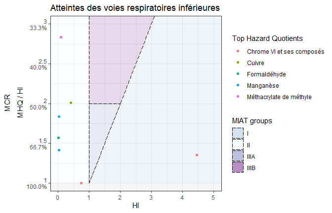

```r
# Add further arguments (regions and log_transform)
charts <- mcr_approach_by_class(values = concentration_values,
                                references = reference_values,
                                classes = classification,
                                FUN = mcr_chart,
                                regions = TRUE,
                                log_transform = FALSE)

# Look at the chart of the second class (and add the class name as a title with ggplot2)
charts[[2]] + ggtitle(names(charts)[2])
```

## 3.3. Contingency tables according to classes

Finally, contingency tables can also be built for each class. The first one:

```r
# Build one contingency table for each class and look at some of them
mcr_approach_by_class(values = concentration_values,
                      references = reference_values,
                      classes = classification,
                      FUN = thq_pairs)[10:12]
```

```
## $`Atteintes hépatiques`
## NULL
##
## $`Atteintes oculaires`
##                           Butanone Chrome VI et ses composés Cuivre Styrène
## Butanone                         0                         0      1       0
## Chrome VI et ses composés        0                         1      0       0
## Cuivre                           1                         0      0       0
## Styrène                          0                         0      0       2
##
## $`Atteintes sur le développement du fœtus, de l’embryon et/ou de l’enfant`
##                           Chrome VI et ses composés Styrène
## Chrome VI et ses composés                         1       0
## Styrène                                           0       2
```

`NULL`s result of classes for which no contingency table can be built because the subsets of values don’t contain more than one component or don’t have hazard index greater than 1.

The second contingency table:

```r
# Build one contingency table for each class and look at some of them
mcr_approach_by_class(values = concentration_values,
                      references = reference_values,
                      classes = classification,
                      FUN = thq_by_group)[10:12]
```

```
## $`Atteintes hépatiques`
##                       I II IIIA IIIB
## 1-Méthoxypropane-2-ol 0  2    0    0
##
## $`Atteintes oculaires`
##                           I II IIIA IIIB
## Acétone                   0  1    0    0
## Benzène                   0  1    0    0
## Butanone                  1  0    0    0
## Chrome VI et ses composés 1  1    0    0
## Méthacrylate de méthyle   0  1    0    0
## Styrène                   2  0    0    0
##
## $`Atteintes sur le développement du fœtus, de l’embryon et/ou de l’enfant`
##                           I II IIIA IIIB
## Butanone                  1  0    0    0
## Chrome VI et ses composés 1  1    0    0
## Styrène                   2  0    0    0
## Toluène                   0  1    0    0
```

Additional arguments related to the functions `thq_pairs` and `thq_by_group` can also be used when calling `mcr_approach_by_class`.

# 4. Data management

## 4.1. Classification management

For this section, we will use a simple classification system assigning classes C1 to C8 to elements A, B, C, D and E:

```r
classification_1 <- list(A = c("C5", "C6", "C8"),
                         B = "C8",
                         C = c("C3", "C8"),
                         D = c("C1", "C3", "C4", "C6"),
                         E = c("C2", "C4", "C5", "C7", "C8"))
classification_1
```

```
## $A
## [1] "C5" "C6" "C8"
##
## $B
## [1] "C8"
##
## $C
## [1] "C3" "C8"
##
## $D
## [1] "C1" "C3" "C4" "C6"
##
## $E
## [1] "C2" "C4" "C5" "C7" "C8"
```

### 4.1.1. Listing and counting classes

Two functions allow to perform set operation on such a list: `union_on_list` and `intersect_on_list`. The former allows to identify the list of classes involved by two or more elements. The latter allows to identify the common classes between two or more elements. The specified indices can be either numbers or names.

```r
# Union with no other argument: identify all classes involved by all elements
union_on_list(classification_1)
```

```
## [1] "C1" "C2" "C3" "C4" "C5" "C6" "C7" "C8"
```

```r
# Union with a set of indices: identify classes involved by specific elements
union_on_list(classification_1,
              indices = c("A", "C"))
```

```
## [1] "C3" "C5" "C6" "C8"
```

```r
# Intersection with no other argument: identify the common classes between all elements
intersect_on_list(classification_1)
```

```
## character(0)
```

```r
# Intersection with a set of indices: identify the common classes between specific elements
intersect_on_list(classification_1,
                  indices = c(1, 3))
```

```
## [1] "C8"
```

Another function allows to build a frequency table of the counts of each class: `table_on_list`. In this case too, specified indices can be either numbers or names. But another argument (`with_zero`) allows to add in the table classes of the list that are not encountered at any of these indices.

```r
# Overall table
table_on_list(classification_1)
```

```
## C1 C2 C3 C4 C5 C6 C7 C8
##  1  1  2  2  2  2  1  4
```

```r
# Table of classes encountered at specific indices
table_on_list(classification_1,
              indices = c(1, 2, 3))
```

```
## C3 C5 C6 C8
##  1  1  1  3
```

```r
# Table of classes encountered for specific elements, showing all classes
table_on_list(classification_1,
              indices = c("A", "B", "C"),
              with_zero = TRUE)
```

```
## C1 C2 C3 C4 C5 C6 C7 C8
##  0  0  1  0  1  1  0  3
```

Moreover, we can ask for several frequency tables using a matrix or a list of indices. In this case, if `with_zero` is set to `TRUE`, the result is simplified into a single matrix.

```r
# Preparing three vectors of indices in a matrix
indices_matrix <- matrix(c("A", "B", "C",
                           "A", "B", "D",
                           "B", "C", "E"),
                         nrow = 3,
                         byrow = TRUE)
# Building of tables
table_on_list(classification_1, indices_matrix)
```

```
## [[1]]
## C3 C5 C6 C8
##  1  1  1  3
##
## [[2]]
## C1 C3 C4 C5 C6 C8
##  1  1  1  1  2  2
##
## [[3]]
## C2 C3 C4 C5 C7 C8
##  1  1  1  1  1  3
```

```r
# Adding names to the three vectors of indices
rownames(indices_matrix) <- c("v1", "v2", "v3")

# Building of tables
table_on_list(classification_1,
              indices_matrix,
              with_zero = TRUE)
```

```
##    C1 C2 C3 C4 C5 C6 C7 C8
## v1  0  0  1  0  1  1  0  3
## v2  1  0  1  1  1  2  0  2
## v3  0  1  1  1  1  0  1  3
```

```r
# Preparing three vectors of indices in a list
indices_list <- list(c("A", "B", "C"),
                     c("A", "B"),
                     "A")
# Building of tables
table_on_list(classification_1, indices_list)
```

```
## [[1]]
## C3 C5 C6 C8
##  1  1  1  3
##
## [[2]]
## C5 C6 C8
##  1  1  2
##
## [[3]]
## C5 C6 C8
##  1  1  1
```

```r
# Building of tables of all classes
table_on_list(classification_1,
              indices_list,
              with_zero = TRUE)
```

```
##      C1 C2 C3 C4 C5 C6 C7 C8
## [1,]  0  0  1  0  1  1  0  3
## [2,]  0  0  0  0  1  1  0  2
## [3,]  0  0  0  0  1  1  0  1
```

### 4.1.2. Change the classification structure

If we want to turn the classification list into a binary matrix, we can use the function `coerce_list`. In such a matrix, `TRUE` indicates that a specific element is part of a specific class.

```r
classification_matrix <- coerce_list(classification_1, to = "logical matrix")
classification_matrix
```

```
##      C1    C2    C3    C4    C5    C6    C7    C8
## A FALSE FALSE FALSE FALSE  TRUE  TRUE FALSE  TRUE
## B FALSE FALSE FALSE FALSE FALSE FALSE FALSE  TRUE
## C FALSE FALSE  TRUE FALSE FALSE FALSE FALSE  TRUE
## D  TRUE FALSE  TRUE  TRUE FALSE  TRUE FALSE FALSE
## E FALSE  TRUE FALSE  TRUE  TRUE FALSE  TRUE  TRUE
```

Conversely, we can use the function `coerce_to_list` to turn a classification matrix into a list:

```r
classification_list <- coerce_to_list(classification_matrix)
classification_list
```

```
## $A
## [1] "C5" "C6" "C8"
##
## $B
## [1] "C8"
##
## $C
## [1] "C3" "C8"
##
## $D
## [1] "C1" "C3" "C4" "C6"
##
## $E
## [1] "C2" "C4" "C5" "C7" "C8"
```

However, if the initial structure is a list in which classes are the names and elements are the values, as in the following…

```r
classification_2 <- list(C1 = "D",
                         C2 = "E",
                         C3 = c("C", "D"),
                         C4 = c("D", "E"),
                         C5 = c("A", "E"),
                         C6 = c("A", "D"),
                         C7 = "E",
                         C8 = c("A", "B", "C", "E"))
classification_2
```

```
## $C1
## [1] "D"
##
## $C2
## [1] "E"
##
## $C3
## [1] "C" "D"
##
## $C4
## [1] "D" "E"
##
## $C5
## [1] "A" "E"
##
## $C6
## [1] "A" "D"
##
## $C7
## [1] "E"
##
## $C8
## [1] "A" "B" "C" "E"
```

… we can use the function `invert_list` to get the structure to be similar to the first one presented:

```r
invert_list(classification_2)
```

```
## $A
## [1] "C5" "C6" "C8"
##
## $B
## [1] "C8"
##
## $C
## [1] "C3" "C8"
##
## $D
## [1] "C1" "C3" "C4" "C6"
##
## $E
## [1] "C2" "C4" "C5" "C7" "C8"
```

In the same way, we can go from a structure listing the classes to which each element belongs to, to a structure listing the elements belonging to each of the classes:

```r
invert_list(classification_1)
```

```
## $C1
## [1] "D"
##
## $C2
## [1] "E"
##
## $C3
## [1] "C" "D"
##
## $C4
## [1] "D" "E"
##
## $C5
## [1] "A" "E"
##
## $C6
## [1] "A" "D"
##
## $C7
## [1] "E"
##
## $C8
## [1] "A" "B" "C" "E"
```

Finally, if we have a data frame or a matrix in which two columns define the associations between the elements and the classes as in the following…

```r
classification_3 <- matrix(c(rep("A", 3), "B", rep("C", 2), rep("D", 4), rep("E", 5),
                             "C5", "C6", "C8",
                             "C8",
                             "C3", "C8",
                             "C1", "C3", "C4", "C6",
                             "C2", "C4", "C5", "C7", "C8"),
                           ncol = 2,
                           dimnames = list(NULL, c("element", "class")))
classification_3
```

```
##       element class
##  [1,] "A"     "C5"
##  [2,] "A"     "C6"
##  [3,] "A"     "C8"
##  [4,] "B"     "C8"
##  [5,] "C"     "C3"
##  [6,] "C"     "C8"
##  [7,] "D"     "C1"
##  [8,] "D"     "C3"
##  [9,] "D"     "C4"
## [10,] "D"     "C6"
## [11,] "E"     "C2"
## [12,] "E"     "C4"
## [13,] "E"     "C5"
## [14,] "E"     "C7"
## [15,] "E"     "C8"
```

… we can also use the function `coerce_to_list` to get the structure to be similar to the first one presented:

```r
coerce_to_list(classification_3)
```

```
## $A
## [1] "C5" "C6" "C8"
##
## $B
## [1] "C8"
##
## $C
## [1] "C3" "C8"
##
## $D
## [1] "C1" "C3" "C4" "C6"
##
## $E
## [1] "C2" "C4" "C5" "C7" "C8"
```

## 4.2. Value management

### 4.2.1. Components of the sets

Having our list of values which are concentration values for specific substances, we can call `coerce_list` to know which substances are present in which sets of values by coercing the list to a binary matrix. Each line refers to one set of values and each column refers to one name found in the values of the list.

```r
# Just look at some columns
coerce_list(concentration_values,
            to = "logical matrix",
            by_name = TRUE)[, c(4:5,8,12:14,23:25)]
```

```
##     Acétone Aluminium Butanone Cuivre Ethanol   Fer Styrène Toluène  Zinc
## S1    FALSE     FALSE    FALSE  FALSE    TRUE FALSE   FALSE   FALSE FALSE
## S2    FALSE     FALSE    FALSE  FALSE   FALSE FALSE   FALSE   FALSE FALSE
## S3     TRUE     FALSE    FALSE  FALSE   FALSE FALSE    TRUE   FALSE FALSE
## S4    FALSE     FALSE    FALSE  FALSE   FALSE FALSE   FALSE   FALSE FALSE
## S5    FALSE     FALSE    FALSE  FALSE   FALSE FALSE   FALSE   FALSE FALSE
## S6     TRUE     FALSE    FALSE  FALSE   FALSE FALSE   FALSE    TRUE FALSE
## S7    FALSE      TRUE    FALSE  FALSE   FALSE  TRUE   FALSE   FALSE  TRUE
## S8    FALSE     FALSE     TRUE   TRUE   FALSE FALSE   FALSE   FALSE  TRUE
## S9     TRUE     FALSE    FALSE  FALSE   FALSE FALSE    TRUE   FALSE FALSE
## S10   FALSE     FALSE    FALSE  FALSE   FALSE FALSE   FALSE   FALSE FALSE
## S11   FALSE     FALSE    FALSE  FALSE   FALSE  TRUE   FALSE   FALSE FALSE
## S12   FALSE     FALSE    FALSE  FALSE   FALSE  TRUE   FALSE   FALSE FALSE
## S13   FALSE     FALSE    FALSE  FALSE   FALSE FALSE   FALSE   FALSE FALSE
## S14   FALSE     FALSE    FALSE  FALSE   FALSE FALSE   FALSE   FALSE FALSE
```

The argument `by_name` allows to construct the matrix on the names of the values instead of the values themselves.

### 4.2.2. Reduction of sets of values

In the list of sets of values, some of these sets contains several values for the same component name, like in the following:

```r
# Let's look at the 2nd and 4th sets of values
concentration_values[c(2,4)]
```

```
## $S2
## Formaldéhyde Formaldéhyde      Benzène
##        0.007        0.004        0.050
##
## $S4
## Hydrocarbures aliphatiques et alicycliques
##                                         10
## Hydrocarbures aliphatiques et alicycliques
##                                         42
## Hydrocarbures aliphatiques et alicycliques
##                                         26
## Hydrocarbures aliphatiques et alicycliques
##                                          8
```

We can use the function `reduce_sets` to apply a specific function on each subset of value corresponding to each name in order to keep only one value for each name in each set of values. This specific function is given as argument `FUN` and can be any function taking a numeric vector as input and returning one single value. It can be a custom function or a base function like `min`, `max`, `median`, etc.

```r
# Reduce the sets of values by taking the minimum value associated with each name
new_values <- reduce_sets(concentration_values,
                          FUN = min)

# Let's look at the new 2nd and 4th sets of values
new_values[c(2,4)]
```

```
## $S2
## Formaldéhyde      Benzène
##        0.004        0.050
##
## $S4
## Hydrocarbures aliphatiques et alicycliques
##                                          8
```

### 4.2.3. Subset corresponding to a specific class

It is possible to extract from the sets of values those which are related to a specific class. For that, we will use the function `subset_from_class` and choose one from the set of class names (defined in section 1.2. Classification):

```r
# Extraction of the subsets for the ninth class
subsets <- subset_from_class(values = concentration_values,
                             references = reference_values,
                             classes = classification,
                             class_name = class_names[9])
```

The output of this function is a list containing two subsets: `values`, the subset of `concentration_values` corresponding to the class `class_name`; `references`, the subset of `reference_values` corresponding to this same class.

Before looking at the subsets related to the chosen class, we can compare their lengths to those of the complete sets of values.

```r
cat("Number of values of each set of concentration values:\n")
lengths(concentration_values)

cat("\nNumber of values related to the ninth class :\n")
lengths(subsets[["values"]])
```

```
## Number of values of each set of concentration values:
##  S1  S2  S3  S4  S5  S6  S7  S8  S9 S10 S11 S12 S13 S14
##  24   3  21   4   1   3  10  15  30   6   6   5   2   1
##
## Number of values related to the ninth class :
##  S1  S3  S6  S7  S8  S9 S11 S12
##   8  21   2   2   1  30   1   1
```

We can see that only 8 sets of concentration values contain substances related to the class of interest.

Let’s take a look at the values from the 6th set, in which only two of the three values were kept:

```r
cat("Values of the sixth set of concentration values:\n")
concentration_values$S6

cat("\nValues of the sixth set of concentration values related to the ninth class:\n")
subsets[["values"]]$S6
```

```
## Values of the sixth set of concentration values:
##                                    Acétone
##                                         44
##                                    Toluène
##                                          4
## Hydrocarbures aliphatiques et alicycliques
##                                         48
##
## Values of the sixth set of concentration values related to the ninth class:
## Acétone Toluène
##      44       4
```

To finish, we can look at the subset of references, which will also give the set of substances related to the class:

```r
subsets[["references"]]
```

```
##               Ethanol               Acétone              Butanone
##                1900.0                1210.0                 600.0
## 1-Méthoxypropane-2-ol               Styrène               Toluène
##                 188.0                 100.0                  76.8
##             Manganèse
##                   1.0
```

# References

Price PS, Han X (2011). Maximum cumulative ratio (MCR) as a tool for assessing the value of performing a cumulative risk assessment. *International Journal of Environmental Research and Public Health*. 8(6): 2212-2225. https://doi.org/10.3390/ijerph8062212.

Reyes JM, Price PS (2018). An analysis of cumulative risks based on biomonitoring data for six phthalates using the Maximum Cumulative Ratio. *Environment International*, 112, 77-84. https://doi.org/10.1016/j.envint.2017.12.008.

De Brouwere K, et al. (2014). Application of the maximum cumulative ratio (MCR) as a screening tool for the evaluation of mixtures in residential indoor air. *The Science of the Total Environment*, 479-480, 267-276. https://doi.org/10.1016/j.scitotenv.2014.01.083.

# List of datasets, functions, classes and methods

The package help page: uom.dat

## Datasets

Datasets used as examples:

- oedb_sample
- substances_information
- TS_instance
- TA_instance

## About transaction sets

The class: TransactionSet

Making *TransactionSet* objects:

- transaction.set
- make_transactions
- make_OE_transactions
- [, [[, $ and [<-, [[<-, $<-
- subset
- reorder
- remove_items
- remove_empty_trx

Search in transactions:

- get_all_items
- get_all_years
- get_itemsets
- get_items_from_info
- get_info_from_items

Search for transactions:

- get_trx_from_items
- get_trx_from_info
- get_complex_trx
- get_simple_trx

Computations on transactions:

- complexity_index
- complexity_ratio
- co_occurrence_matrix

Making charts about transactions:

- itemset_chart
- co_occurrence_chart

Saving transactions:

- export

## About transaction analyzes

The class: TransactionAnalyzer

Making *TransactionAnalyzer* objects:

- transaction.analyzer
- init and is_init
- reset
- [ and [<-

Search for transactions, nodes or patterns:

- get_trx_from_category
- get_nodes
- get_patterns
- get_complexes
- get_isolates
- get_non_isolates

Computations on nodes and patterns:

- frequency_by_complexity
- dynamic_status

Search for links between nodes or between patterns:

- get_links

Extracting association rules and switching between mathematical notation and vector notation for sets:

- extract_rules
- vector_notation
- set_notation

Find item names and colors associated with item identifiers and category values associated with itemsets:

- get_item_names
- get_item_colors
- category_values

Making charts:

- itemset_chart
- co_occurrence_chart
- category_tree_chart
- spectrum_chart
- spectrosome_chart
- rules_chart

Computations on spectrosome graphs:

- degree
- network_density

Saving nodes, patterns or association rules:

- export

## About the maximum cumulative ratio approach

Computation of the main indicators:

- hazard_quotient
- hazard_index
- maximum_hazard_quotient
- maximum_cumulative_ratio
- missed_toxicity

Computation of additional indicators:

- reciprocal_of_mcr
- top_hazard_quotient
- classify_mixture

Summarising indicators:

- mcr_summary
- mcr_chart
- thq_pairs
- thq_by_group

Application of the approach according to a classification:

- mcr_approach_by_class
- mcr_summary_by_class
- mcr_chart_by_class
- thq_pairs_by_class
- thq_by_group_by_class

Subsets and reduction of sets:

- reduce_sets
- subset_from_class

## About lists

Computations on lists:

- intersect_on_list
- union_on_list
- table_on_list

Transformation of lists and transformation into lists:

- invert_list
- coerce_list
- coerce_to_list

Search in lists:

- nth_values